# STA403-1 第二次作业

金科 201756010

### 第三周任务：P119 第10题

（a）描述统计

```r
library(ISLR)
library(corrplot)
data = Weekly
```

```r
summary(data)
```

```
##       Year           Lag1               Lag2               Lag3
##  Min.   :1990   Min.   :-18.1950   Min.   :-18.1950   Min.   :-18.1950
##  1st Qu.:1995   1st Qu.: -1.1540   1st Qu.: -1.1540   1st Qu.: -1.1580
##  Median :2000   Median :  0.2410   Median :  0.2410   Median :  0.2410
##  Mean   :2000   Mean   :  0.1506   Mean   :  0.1511   Mean   :  0.1472
##  3rd Qu.:2005   3rd Qu.:  1.4050   3rd Qu.:  1.4090   3rd Qu.:  1.4090
##  Max.   :2010   Max.   : 12.0260   Max.   : 12.0260   Max.   : 12.0260
##       Lag4               Lag5              Volume
##  Min.   :-18.1950   Min.   :-18.1950   Min.   :0.08747
##  1st Qu.: -1.1580   1st Qu.: -1.1660   1st Qu.:0.33202
##  Median :  0.2380   Median :  0.2340   Median :1.00268
##  Mean   :  0.1458   Mean   :  0.1399   Mean   :1.57462
##  3rd Qu.:  1.4090   3rd Qu.:  1.4050   3rd Qu.:2.05373
##  Max.   : 12.0260   Max.   : 12.0260   Max.   :9.32821
##      Today          Direction
##  Min.   :-18.1950   Down:484
##  1st Qu.: -1.1540   Up  :605
##  Median :  0.2410
##  Mean   :  0.1499
##  3rd Qu.:  1.4050
##  Max.   : 12.0260
```

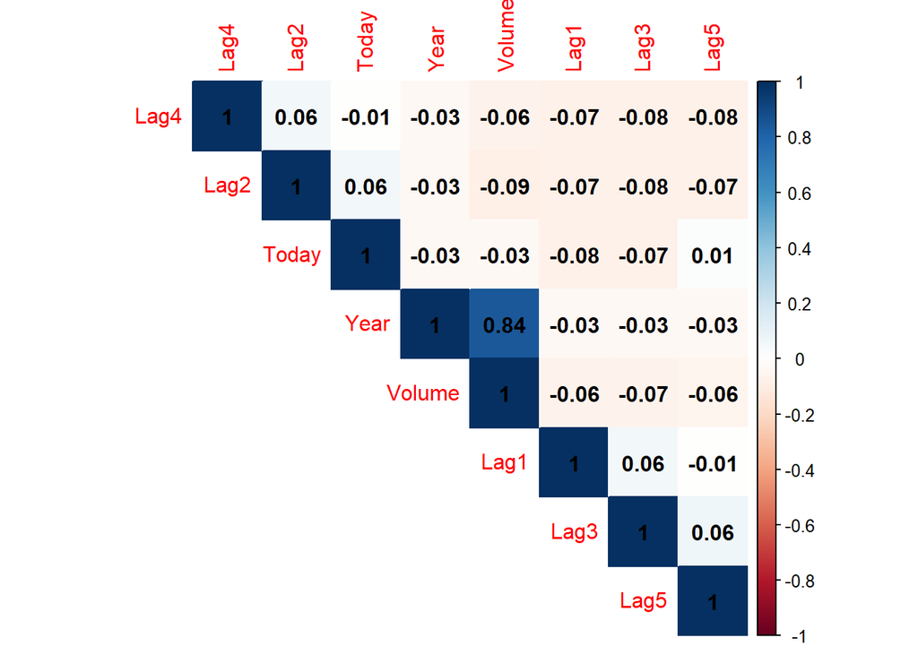

```r
# 计算相关矩阵
corr <- cor(data[, 1:8])
corrplot(corr, method = 'color', type = 'upper',
         order = 'hclust', addCoef.col = 'black')
```

如图所示，当前的投资回报率与先前的投资回报率相关性很小，只有变量`Year`和`Volume`存在明显的相关性。

（b）使用`Lag1`到`Lag5`和`Volume`拟合逻辑斯谛回归模型预测`Direction`

```r
model <- glm(Direction ~ Lag1 + Lag2 + Lag3 + Lag4 + Lag5 + Volume,
             data = data, family = binomial)
```

提取模型系数的P值信息显示如下

```r
summary(model)$coefficients[, 4]
```

```
## (Intercept)        Lag1        Lag2        Lag3        Lag4        Lag5
## 0.001898848 0.118144368 0.029601361 0.546923890 0.293653342 0.583348244
##      Volume
## 0.537674762
```

在模型中变量`Lag2`在0.05的水平下显著。

（c）

```r
model_predict <- predict(model, type = "response")
model_predict[model_predict > 0.5] <- "Up"
model_predict[model_predict != "Up"] <- "Down"
table(model_predict, data$Direction)
```

```
##
## model_predict Down  Up
##          Down   54  48
##          Up    430 557
```

计算模型准确度

```r
cat("\n The accuracy is", mean(model_predict == data$Direction))
```

```
##
##  The accuracy is 0.5610652
```

- 真值为“Down”时预测正确的概率为$\frac{54}{54+430} = 11.16\%$；
- 真值为“Up”时预测正确的概率为$\frac{557}{48+557} = 92.07\%$。

（d）使用1990至2008年的数据作为训练集拟合模型，且只把`Lag2`作为预测变量

```r
# 切分数据集
flag = data$Year %in% 1990:2008
train_data = data[flag, ]
test_data = data[!flag, ]

# 训练逻辑斯谛回归模型
neoModel <- glm(Direction ~ Lag2, data = train_data, family = binomial)

# 在测试集中进行预测
neoModelPredict <- predict(neoModel, test_data, type = "response")
neoModelPredict <- ifelse(neoModelPredict > 0.5, "Up", "Down")

# 计算混淆矩阵
table(neoModelPredict, test_data$Direction)
```

```
##
## neoModelPredict Down Up
##            Down    9  5
##            Up     34 56
```

```r
cat("\n The new accuracy is",
    mean(neoModelPredict == test_data$Direction))
```

```
##
##  The new accuracy is 0.625
```

（e）使用LDA重复（d）中过程

```r
library(MASS)
```

```r
ldaModel <- lda(Direction ~ Lag2, data = train_data)
ldaModelPredict <- predict(ldaModel, test_data,
                           type = "response") $ class

# 计算混淆矩阵
table(ldaModelPredict, test_data$Direction)
```

```
##
## ldaModelPredict Down Up
##            Down    9  5
##            Up     34 56
```

```r
cat("\n LDA accuracy is",
    mean(ldaModelPredict == test_data$Direction))
```

```
##
##  LDA accuracy is 0.625
```

（f）使用QDA重复（d）中过程

```r
qdaModel <- qda(Direction ~ Lag2, data = train_data)
qdaModelPredict <- predict(qdaModel, test_data,
                           type = "response") $ class

# 计算混淆矩阵
table(qdaModelPredict, test_data$Direction)
```

```
##
## qdaModelPredict Down Up
##            Down    0  0
##            Up     43 61
```

```r
cat("\n QDA accuracy is",
    mean(qdaModelPredict == test_data$Direction))
```

```
##
##  QDA accuracy is 0.5865385
```

QDA模型竟然将所有数据预测为“Up”！

（g）使用$K=1$的KNN重复（d）中过程

```r
library(class)
```

```r
set.seed(1)
knnModelPredict = knn(as.matrix(train_data$Lag2),
                      as.matrix(test_data$Lag2),
                      train_data$Direction, k = 1)

# 计算混淆矩阵
table(knnModelPredict, test_data$Direction)
```

```
##
## knnModelPredict Down Up
##            Down   21 30
##            Up     22 31
```

```r
cat("\n KNN (k=1) accuracy is",
    mean(knnModelPredict == test_data$Direction))
```

```
##
##  KNN (k=1) accuracy is 0.5
```

（h）对比各模型结果可知逻辑斯谛回归和LDA的结果最好

```r
cat("Logistic    ", mean(neoModelPredict == test_data$Direction),
    "\n   LDA      ", mean(ldaModelPredict == test_data$Direction),
    "\n   QDA    ", mean(qdaModelPredict == test_data$Direction),
    "\n KNN(K=1)    ", mean(knnModelPredict == test_data$Direction))
```

```
## Logistic     0.625
##    LDA       0.625
##    QDA     0.5865385
##  KNN(K=1)     0.5
```

（i）对不同K值应用KNN模型

```r
knnResults <- double(0)
n = 1
for (i in c(1:10)) {
    for (k in 1:200) {
        set.seed(i)
        knnModelPredict = knn(as.matrix(train_data$Lag2),
                      as.matrix(test_data$Lag2),
                      train_data$Direction, k = k)
        knnResults[n] <- mean(knnModelPredict == test_data$Direction)
        n = n + 1
}
}
knnResults <- data.frame(1:200, knnResults)
names(knnResults) <- c("K", "accuracy")
```

```r
# 将结果可视化
library(ggplot2)
```

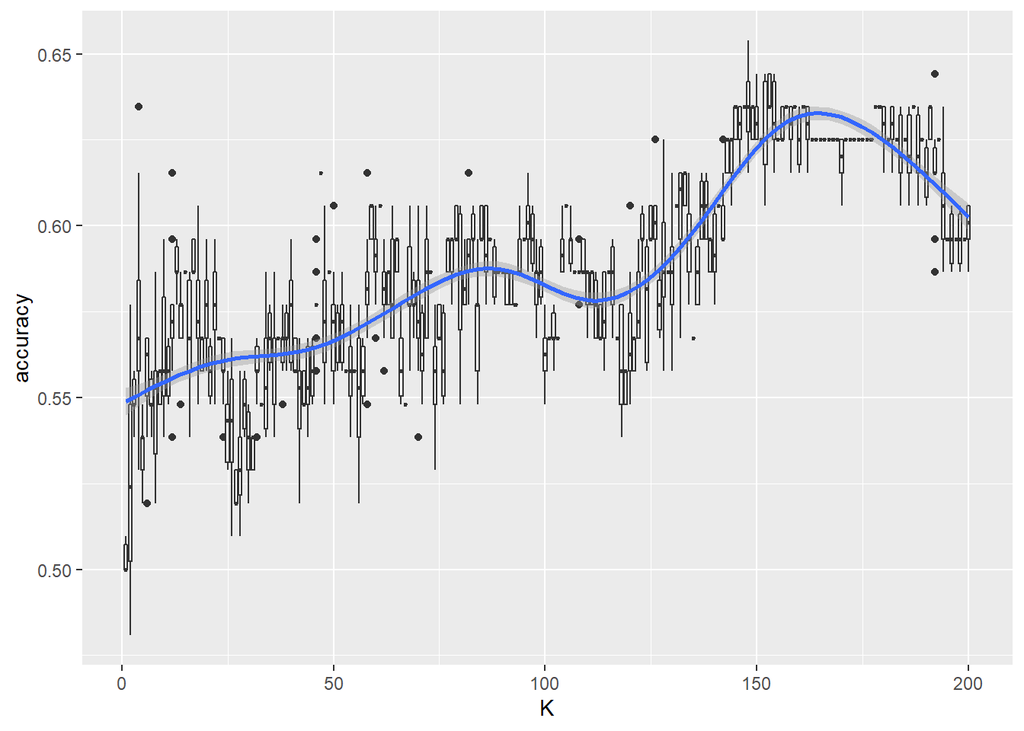

```r
ggplot(knnResults, aes(x = K, y = accuracy)) + geom_boxplot(aes(group = K)) + geom_smooth()
```

如图所示，随着K逐渐增大，模型精确度大体上先增大后减小。其中当K大约取150时精确度达到最大，此时计算混淆矩阵

```r
set.seed(1)
knnModelPredict = knn(as.matrix(train_data$Lag2),
                      as.matrix(test_data$Lag2),
                      train_data$Direction, k = 150)

# 计算混淆矩阵
table(knnModelPredict, test_data$Direction)
```

```
##
## knnModelPredict Down Up
##            Down    9  5
##            Up     34 56
```

```r
cat("\n KNN (k=150) accuracy is",
    mean(knnModelPredict == test_data$Direction))
```

```
##
##  KNN (k=150) accuracy is 0.625
```

在原有LDA模型中增加`Lag1`和`Lag2`^2两项

```r
neoLdaModel <- lda(Direction ~ Lag1 + Lag2 + I(Lag2^2),
                   data = train_data)
neoLdaModelPredict <- predict(neoLdaModel, test_data,
                              type = "response") $ class

# 计算混淆矩阵
table(neoLdaModelPredict, test_data$Direction)
```

```
##
## neoLdaModelPredict Down Up
##               Down    8 11
##               Up     35 50
```

```r
cat("\n neoLDA accuracy is",
    mean(neoLdaModelPredict == test_data$Direction))
```

```
##
##  neoLDA accuracy is 0.5576923
```

在原有QDA模型中增加`Lag2`和`Lag3`的交互项

```r
neoQdaModel <- qda(Direction ~ Lag2 + Lag2:Lag3,
                   data = train_data)
neoQdaModelPredict <- predict(neoQdaModel, test_data,
                              type = "response") $ class

# 计算混淆矩阵
table(neoQdaModelPredict, test_data$Direction)
```

```
##
## neoQdaModelPredict Down Up
##               Down    6  7
##               Up     37 54
```

```r
cat("\n neoQDA accuracy is",
    mean(neoQdaModelPredict == test_data$Direction))
```

```
##
##  neoQDA accuracy is 0.5769231
```

### 第四周任务（1）：P138 第8题

在一个模拟数据集上使用交叉验证法

1. 生成的模拟数据集如下：

```r
set.seed(1)
y = rnorm(100)
x = rnorm(100)
y = x - 2 * x^2 + rnorm(100)
```

其中$n=100$、$p=2$，模型为$y=x-2x^2+\varepsilon$。

2. 作X对Y的散点图，讨论结果

```r
library(ggplot2)
```

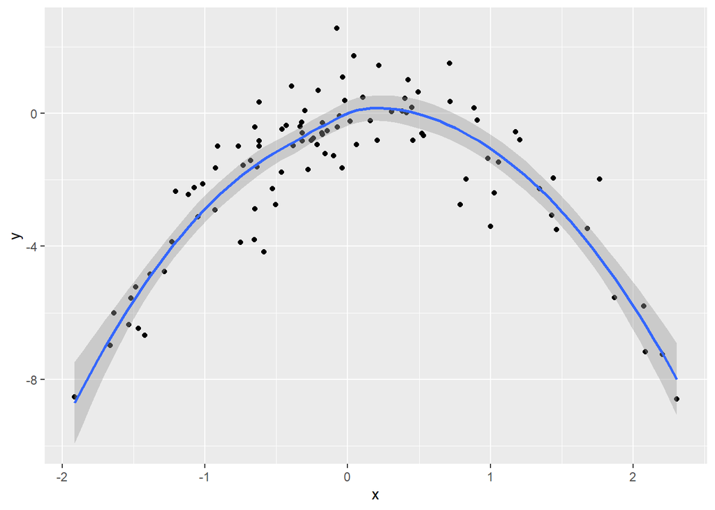

```r
ggplot(data.frame(y,x), aes(x = x, y = y)) + geom_point() + geom_smooth()
```

如图所示，Y与X的图像形如开口向下的抛物线。

3. 最小二乘法拟合下面四个模型产生的LOOCV误差
- $Y = \beta_0 + \beta_1X + \varepsilon$
- $Y = \beta_0 + \beta_1X + \beta_1X^2 + \varepsilon$
- $Y = \beta_0 + \beta_1X + \beta_1X ^2+ \beta_1X^3 + \varepsilon$
- $Y = \beta_0 + \beta_1X + \beta_1X^2 + \beta_1X^3 + \beta_1X^4 + \varepsilon$

```r
library(boot)
```

```r
loocv_error <- function(data, range) {
  result <- numeric(length(range))
  for (i in range) {
    glm <- glm(y ~ poly(x, i), data = data)
    result[i] <- cv.glm(data, glm)$delta[1]
  }
  return(result)
}

set.seed(1)
error <- loocv_error(data.frame(x,y), 1:4)
error
```

```
## [1] 5.890979 1.086596 1.102585 1.114772
```

4. 用另外的随机种子重复步骤(c)

```r
set.seed(2)
error <- loocv_error(data.frame(x,y), 1:4)
error
```

```
## [1] 5.890979 1.086596 1.102585 1.114772
```

设另外的随机种子对LOOCV误差没有影响，因为该方法在训练集和验证集的分割上不存在随机性。

5. 在步骤(c)的结果中，模型$Y = \beta_0 + \beta_1X + \beta_1X^2 + \varepsilon$具有最小的LOOCV误差(1.086596)，因为模拟函数本身为二次型，过高的阶数会使模型过拟合到随机噪声上，增大泛化误差。
6. 讨论用最小二乘法拟合(c)中的每个模型所得到的系数估计的统计意义。

```r
summary(lm(y ~ poly(x, 4)))
```

```
##
## Call:
## lm(formula = y ~ poly(x, 4))
##
## Residuals:
##     Min      1Q  Median      3Q     Max
## -2.8914 -0.5244  0.0749  0.5932  2.7796
##
## Coefficients:
##             Estimate Std. Error t value Pr(>|t|)
## (Intercept)  -1.8277     0.1041 -17.549   <2e-16 ***
## poly(x, 4)1   2.3164     1.0415   2.224   0.0285 *
## poly(x, 4)2 -21.0586     1.0415 -20.220   <2e-16 ***
## poly(x, 4)3  -0.3048     1.0415  -0.293   0.7704
## poly(x, 4)4  -0.4926     1.0415  -0.473   0.6373
## ---
## Signif. codes:  0 '***' 0.001 '**' 0.01 '*' 0.05 '.' 0.1 ' ' 1
##
## Residual standard error: 1.041 on 95 degrees of freedom
## Multiple R-squared:  0.8134, Adjusted R-squared:  0.8055
## F-statistic: 103.5 on 4 and 95 DF,  p-value: < 2.2e-16
```

结果表明$x$、$x^2$两项的系数在0.05的水平上显著，与交叉验证法得到的结论一致。

### 第四周任务（2）：P138 第9题

考虑*MASS*程序包中的*Boston*住房数据集

```r
library(MASS)
library(boot)
data = Boston
```

1. 给出一个对`medv`（房价中位数）的总体均值的估计，记为$\hat{\mu}$

```r
medv_mean <- mean(data$medv)
medv_mean
```

```
## [1] 22.53281
```

$\hat{\mu} = 22.53281$。

2. 给出一个对$\hat{\mu}$的标准误差的估计

```r
medv_mean_se <- sd(data$medv) / sqrt(length(data$medv))
medv_mean_se
```

```
## [1] 0.4088611
```

可以认为，对于总体的一个随机样本，平均来说`medv`样本均值与其真值之间相差0.4088611。

3. 用自助法估计$\hat{\mu}$的标准误差

```r
mean_sample <- function(x, index) mean(x[index])
set.seed(1)
medv_boot <- boot(data$medv, statistic = mean_sample, R = 1000)
medv_boot
```

```
##
## ORDINARY NONPARAMETRIC BOOTSTRAP
##
##
## Call:
## boot(data = data$medv, statistic = mean_sample, R = 1000)
##
##
## Bootstrap Statistics :
##     original      bias    std. error
## t1* 22.53281 0.007650791   0.4106622
```

基于自助法可得变量$\hat{\mu}$的标准误差为0.4106622，与刚才(b)中的结果非常接近。

4. 基于自助法估计给出`medv`均值的95%置信区间，并于t.text()相比较

```r
#t.test(data$medv)
#    95 percent confidence interval:
#          21.72953 23.33608

# 打印结果
cat("\n boostrap method: [",
    medv_boot$t0 - 2 * sd(medv_boot$t), ", ",
    medv_boot$t0 + 2*sd(medv_boot$t), "]",
    "\n  t.test method: [",
    21.72953 , ", ", 23.33608, "]")
```

```
##
##  boostrap method: [ 21.71148 ,  23.35413 ]
##   t.test method: [ 21.72953 ,  23.33608 ]
```

5. 基于这个数据集，给出`medv`总体中位数的估计

```r
medv_median <- median(Boston$medv)
medv_median
```

```
## [1] 21.2
```

6. 用自助法估计中位数的标准误差

```r
median_sample <- function(x, index) median(x[index])
set.seed(1)
medv_median_boot <- boot(data$medv, statistic = median_sample, R = 1000)
medv_median_boot
```

```
##
## ORDINARY NONPARAMETRIC BOOTSTRAP
##
##
## Call:
## boot(data = data$medv, statistic = median_sample, R = 1000)
##
##
## Bootstrap Statistics :
##     original  bias    std. error
## t1*     21.2 0.02295   0.3778075
```

由自助法计算结果可得，中位数估计的标准误差为0.3778075。

7. 给出波士顿郊区的`medv`的10%分位数的估计

```r
medv_qntl <- quantile(data$medv, 0.1);
medv_qntl
```

```
##   10%
## 12.75
```

8. 用自助法估计`medv`的10%分位数的估计

```r
qntl_sample <- function(x, index) quantile(x[index], 0.1)
set.seed(1)
medv_qntl_boot <- boot(data$medv, statistic = qntl_sample, R = 1000)
medv_qntl_boot
```

```
##
## ORDINARY NONPARAMETRIC BOOTSTRAP
##
##
## Call:
## boot(data = data$medv, statistic = qntl_sample, R = 1000)
##
##
## Bootstrap Statistics :
##     original  bias    std. error
## t1*    12.75  0.0339   0.4767526
```

由自助法计算结果可得，10%分位数估计的标准误差为0.4767526